# Create and Execute a fMRI preprocessing workflow

In this notebook, I set-up a complete fMRI analysis workflow, following Michael Notter's tutorial and using the data on a different subject (05). I will run the workflow towards the end.

```python
# Get the Node and Workflow object
from nipype import Node, Workflow
from nipype.interfaces import spm

# Specify which SPM to use
from nipype.interfaces.matlab import MatlabCommand
MatlabCommand.set_default_paths('/Users/hanningsu/Documents/MATLAB/spm12')
# This step basically specifies the spm we are going to use. Set the path to where spm is installed
```

```python
spm.SPMCommand.set_mlab_paths(paths='/Users/hanningsu/Documents/MATLAB/spm12/', matlab_cmd='/Applications/MATLAB_R2021a.app/bin/matlab -nodesktop -nosplash')
```

```python
print(spm.SPMCommand().version) # Check the version of spm we are using
```

```
12.7771
```

```python
# Create the workflow here
preproc = Workflow(name='work_preproc', base_dir='/Users/hanningsu/Desktop/Nipype_Tutorial/hands_on_preprocessing/output')
```

# Preprocessing Workflow Structure

## Dataset Studied

The dataset considered in this exercise can be found here: https://legacy.openfmri.org/dataset/ds000114/

According to the page, we know the following about the dataset:

"A test-retest dataset was acquired to validate fMRI tasks used in pre-surgical planning. In particular, five task-related fMRI time series (finger, foot and lip movement, overt verb generation, covert verb generation, overt word repetition, and landmark tasks) were used to investigate which protocols gave reliable single-subject results. Ten healthy participants in their fifties were scanned twice using an identical protocol 2-3 days apart. In addition to the fMRI sessions, high-angular resolution diffusion tensor MRI (DTI), and high-resolution 3D T1-weighted volume scans were acquired."

## Gunzip

```python
from nipype.algorithms.misc import Gunzip
```

```python
# Specify example input file
func_file = "/Users/hanningsu/Desktop/Nipype_Tutorial/data/ds000114/sub-05/ses-test/func/sub-05_ses-test_task-fingerfootlips_bold.nii.gz"

# Initialize Gunzip node
gunzip_func = Node(Gunzip(in_file=func_file), name='gunzip_func')
```

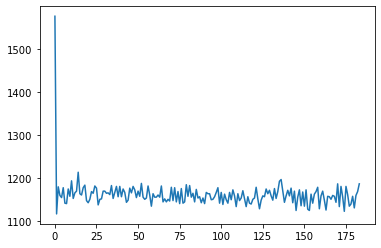

```python
%matplotlib inline
import pylab as plt
import nibabel as nb
plt.plot(nb.load(func_file).get_fdata()[32, 32, 15, :]);
```

In this figure above, we see that at the very beginning there are extreme values, which hint to the fact that steady state was not reached yet. Therefore, we want to exclude the dummy scans from the original data. This can be achieved with FSL's ExtractROI

```python
from nipype.interfaces.fsl import ExtractROI
```

```python
extract = Node(ExtractROI(t_min=4, t_size=-1, output_type='NIFTI'), name="extract")
```

This ExtractROI node can now be connected to the gunzip_func node from above. To do this, we use the following command:

```python
preproc.connect([(gunzip_func, # The source node object
                  extract, # The destination node object
                  [('out_file', # The name of the output field from the source node
                    'in_file' )])]) # The name of the input field from the destination node
```

`connect([(source, dest, [("source_output1", "dest_input1")])] # Code format used above`

## Slice Time Correction

```python
from nipype.interfaces.spm import SliceTiming
```

```python
slice_order = list(range(1, 31, 2)) + list(range(2, 31, 2))
print(slice_order)
```

```
[1, 3, 5, 7, 9, 11, 13, 15, 17, 19, 21, 23, 25, 27, 29, 2, 4, 6, 8, 10, 12, 14, 16, 18, 20, 22, 24, 26, 28, 30]
```

Initialize SliceTming node here

```python
slicetime = Node(SliceTiming(num_slices = 30,
                            ref_slice = 15,
                            slice_order = slice_order, # order of the 30 slices
                            time_repetition = 2.5,
                            time_acquisition = 2.5 - (2.5/30)), # a formula is available for time_acquisition
                name='slicetime')
```

Connect SliceTiming node to the other nodes here

```python
preproc.connect([(extract, slicetime, [('roi_file', 'in_files')])])
```

## Motion Correction

To correct for motion in the scanner, we will be using FSL's MCFLIRT

```python
from nipype.interfaces.fsl import MCFLIRT
```

Initiate MCFLIRT node here

```python
mcflirt = Node(MCFLIRT(mean_vol=True,
                      save_plots=True),
              name="mcflirt")
```

Connect the `MCFLIRT` node to the rest of the workflow

```python
preproc.connect([(slicetime, mcflirt, [('timecorrected_files', 'in_file')])])
```

## Artifact Detection

```python
from nipype.algorithms.rapidart import ArtifactDetect
```

```python
art = Node(ArtifactDetect(norm_threshold=2,
                         zintensity_threshold=2,
                         mask_type='spm_global',
                         parameter_source='FSL',
                         use_differences=[True, False],
                         plot_type='svg'),
          name='art')
```

connect([(source, dest, [("source_output1", "dest_input1"), ("source_output2", "dest_input2") ]) ])

Connect this node to the rest of the workflow, using the code format above

```python
preproc.connect([(mcflirt, art, [('out_file', 'realigned_files'),
                               ('par_file', 'realignment_parameters')])])
```

## Segmentation of anatomical image

```python
from nipype.interfaces.spm import NewSegment
```

```python
# Use the following tissue specification to get a GM and WM probbaility map
tpm_img = '/Users/hanningsu/Documents/MATLAB/spm12/tpm/TPM.nii'
tissue1 = ((tpm_img, 1), 1, (True,False), (False, False))
tissue2 = ((tpm_img, 2), 1, (True,False), (False, False))
tissue3 = ((tpm_img, 3), 2, (True,False), (False, False))
tissue4 = ((tpm_img, 4), 3, (False,False), (False, False))
tissue5 = ((tpm_img, 5), 4, (False,False), (False, False))
tissue6 = ((tpm_img, 6), 2, (False,False), (False, False))
tissues = [tissue1, tissue2, tissue3, tissue4, tissue5, tissue6]
```

```python
# Initiate NewSegment node here
```

```python
segment = Node(NewSegment(tissues=tissues), name='segment')
```

We will again be using a Gunzip node to unzip the anatomical image that we then want to use as input tot the segmentation node, We again also need to specify the anatomical image that we want to use in this case. As before, this will later also be handled directly by the Input/Output stream.

```python
# Specify example input file
anat_file = "/Users/hanningsu/Desktop/Nipype_Tutorial/data/ds000114/sub-05/ses-test/anat/sub-05_ses-test_T1w.nii.gz"

# Initiate Gunzip node
gunzip_anat = Node(Gunzip(in_file=anat_file), name="gunzip_anat")
```

```python
# Connect NewSegment node to the other nodes here
```

```python
preproc.connect([(gunzip_anat, segment, [('out_file', 'channel_files')])])
```

## Compute Coregistration Matrix

As a next step, we will make sure that the functional images are coregistered to the anatomical image. For this, we will use FSL's FLIRT function. As we just created a white matter probability map, we can use this together with the a Boundary-Based Registration (BBR) cost function do optimize the image coregistration. As some helpful notes... use a degree of freedom of 6 specify the cost function as bbr use the schedule='/usr/share/fsl/5.0/etc/flirtsch/bbr.sch'

```python
from nipype.interfaces.fsl import FLIRT
```

```python
# Initiate FLIRT node here
```

```python
coreg = Node(FLIRT(dof=6,
                   cost='bbr',
                   schedule='/usr/local/fsl/etc/flirtsch/bbr.sch',
                   output_type='NIFTI'),
             name="coreg")
```

```python
# Connect FLIRT node to the other nodes here
```

```python
preproc.connect([(gunzip_anat, coreg, [('out_file', 'reference')]),
                 (mcflirt, coreg, [('mean_img', 'in_file')])
])
```

```
connect([(source, dest, [("source_output1", "dest_input1"),
                         ("source_output2", "dest_input2")
                         ])
         ])
```

```python
from nipype.interfaces.fsl import Threshold

# Threshold - Threshold WM probability image
threshold_WM = Node(Threshold(thresh=0.5,
                              args='-bin',
                              output_type='NIFTI'),
                name="threshold_WM")
```

```python
# Select WM segmentation file from segmentation output
def get_wm(files):
    return files[1][0]

# Connecting the segmentation node with the threshold node
preproc.connect([(segment, threshold_WM, [(('native_class_images', get_wm),
                                           'in_file')])])
```

```python
preproc.connect([(threshold_WM, coreg, [('out_file', 'wm_seg')])])
```

## Apply Coregistration Matrix to functional image

```python
# Specify the isometric voxel resolution you want after coregistration
desired_voxel_iso = 4

# Apply coregistration warp to functional images
applywarp = Node(FLIRT(interp='spline',
                       apply_isoxfm=desired_voxel_iso,
                       output_type='NIFTI'),
                 name="applywarp")
```

```python
# Connecting the ApplyWarp node to all the other nodes
preproc.connect([(mcflirt, applywarp, [('out_file', 'in_file')]),
                 (coreg, applywarp, [('out_matrix_file', 'in_matrix_file')]),
                 (gunzip_anat, applywarp, [('out_file', 'reference')])
                 ])
```

## Smoothing

```python
from nipype.interfaces.fsl import SUSAN
#sus.inputs.brightness_threshold = 2000.0
susan = Node(SUSAN(fwhm = 4,
                   brightness_threshold = 2000.0),
              name="susan")
```

```python
preproc.connect([(applywarp, susan, [('out_file', 'in_file')])])
```

## Create Binary Mask

How to implement this step? Could be unnesessary

## Apply the binary mask

```python
# Connect gray matter Mask node to the susan workflow here
```

```python
#preproc.connect([(mask_GM, susan, [('out_file', 'mask_file')])])
#susan no longer takes mask_file as input
```

connect([(source, dest, [("source_output1", "dest_input1")])]) # Code format used above

## Remove linear trends in functioal images

```python
from nipype.algorithms.confounds import TSNR
```

```python
# Initiate TSNR node here
detrend = Node(TSNR(regress_poly=2), name="detrend")
```

```python
# Connect the detrend node to the other nodes here
preproc.connect([(susan, detrend, [('smoothed_file', 'in_file')])])
```

## Datainput with SelectFiles and iterables

```python
# Import the SelectFiles
from nipype import SelectFiles

# String template with {}-based strings
templates = {'anat': 'sub-{subject_id}/ses-{ses_id}/anat/'
                     'sub-{subject_id}_ses-test_T1w.nii.gz',
             'func': 'sub-{subject_id}/ses-{ses_id}/func/'
                     'sub-{subject_id}_ses-{ses_id}_task-{task_id}_bold.nii.gz'}

# Create SelectFiles node
sf = Node(SelectFiles(templates,
                      base_directory='/Users/hanningsu/Desktop/Nipype_Tutorial/data/ds000114',
                      sort_filelist=True),
          name='selectfiles')
sf.inputs.ses_id='test'
sf.inputs.task_id='fingerfootlips'
```

```python
subject_list = ['05']
sf.iterables = [('subject_id', subject_list)]
```

```python
preproc.connect([(sf, gunzip_anat, [('anat', 'in_file')]),
                 (sf, gunzip_func, [('func', 'in_file')])])
```

## Visualize the workflow

```python
# Create preproc output graph
preproc.write_graph(graph2use='colored', format='png', simple_form=True)
```

```
210812-05:39:16,614 nipype.workflow INFO:
	 Generated workflow graph: /Users/hanningsu/Desktop/Nipype_Tutorial/hands_on_preprocessing/output/work_preproc/graph.png (graph2use=colored, simple_form=True).
```

```
'/Users/hanningsu/Desktop/Nipype_Tutorial/hands_on_preprocessing/output/work_preproc/graph.png'
```

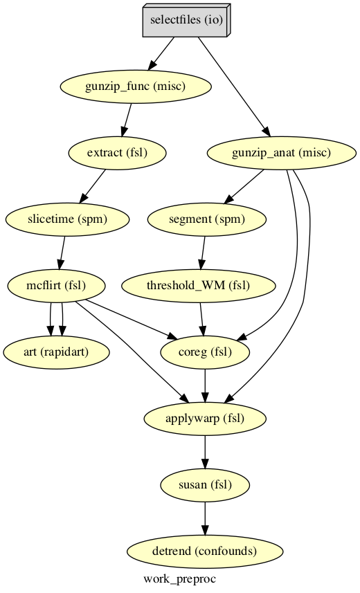

```python
# Visualize the graph
from IPython.display import Image
Image(filename='/Users/hanningsu/Desktop/Nipype_Tutorial/hands_on_preprocessing/output/work_preproc/graph.png', width=750)
```

Note: creating the graph requires graphviz

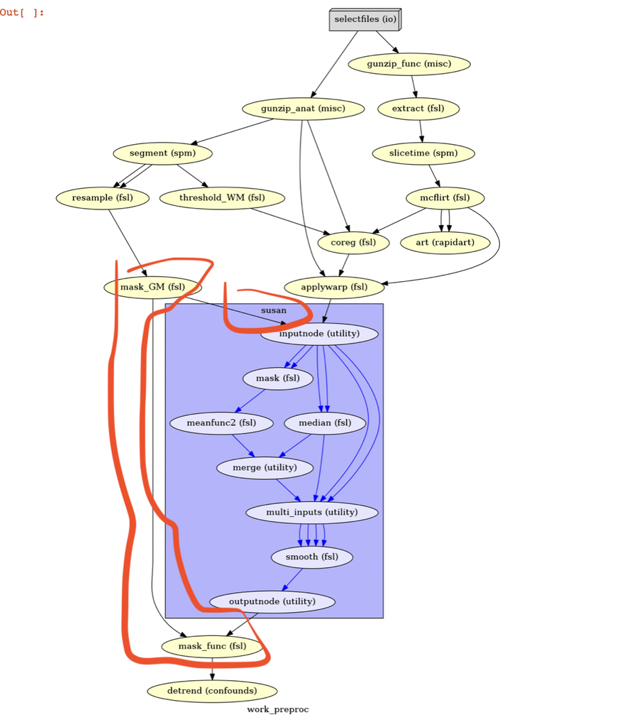

Note: susan no longer takes mask_file as input

## Run the Workflow

```python
preproc.run('MultiProc', plugin_args={'n_procs': 8})
```

```
210812-05:39:36,467 nipype.workflow INFO:
	 Workflow work_preproc settings: ['check', 'execution', 'logging', 'monitoring']
210812-05:39:36,480 nipype.workflow INFO:
	 Running in parallel.
210812-05:39:36,488 nipype.workflow INFO:
	 [MultiProc] Running 0 tasks, and 1 jobs ready. Free memory (GB): 7.20/7.20, Free processors: 8/8.
210812-05:39:38,499 nipype.workflow INFO:
	 [MultiProc] Running 1 tasks, and 0 jobs ready. Free memory (GB): 7.00/7.20, Free processors: 7/8.
                     Currently running:
                       * work_preproc.selectfiles
210812-05:39:44,507 nipype.workflow INFO:
	 [Job 0] Completed (work_preproc.selectfiles).
210812-05:39:44,516 nipype.workflow INFO:
	 [MultiProc] Running 0 tasks, and 2 jobs ready. Free memory (GB): 7.20/7.20, Free processors: 8/8.
210812-05:39:46,513 nipype.workflow INFO:
	 [Job 1] Completed (work_preproc.gunzip_func).
210812-05:39:46,519 nipype.workflow INFO:
	 [Job 6] Completed (work_preproc.gunzip_anat).
210812-05:39:46,524 nipype.workflow INFO:
	 [MultiProc] Running 0 tasks, and 2 jobs ready. Free memory (GB): 7.20/7.20, Free processors: 8/8.
210812-05:39:48,515 nipype.workflow INFO:
	 [Job 2] Completed (work_preproc.extract).
210812-05:39:48,516 nipype.workflow INFO:
	 [MultiProc] Running 1 tasks, and 1 jobs ready. Free memory (GB): 7.00/7.20, Free processors: 7/8.
                     Currently running:
                       * work_preproc.segment
210812-05:39:50,520 nipype.workflow INFO:
	 [MultiProc] Running 2 tasks, and 0 jobs ready. Free memory (GB): 6.80/7.20, Free processors: 6/8.
                     Currently running:
                       * work_preproc.slicetime
                       * work_preproc.segment
210812-05:40:16,582 nipype.workflow INFO:
	 [Job 3] Completed (work_preproc.slicetime).
210812-05:40:16,583 nipype.workflow INFO:
	 [MultiProc] Running 1 tasks, and 1 jobs ready. Free memory (GB): 7.00/7.20, Free processors: 7/8.
                     Currently running:
                       * work_preproc.segment
210812-05:40:18,587 nipype.workflow INFO:
	 [MultiProc] Running 2 tasks, and 0 jobs ready. Free memory (GB): 6.80/7.20, Free processors: 6/8.
                     Currently running:
```

[output cut: 39 more lines]

```
	 [MultiProc] Running 1 tasks, and 0 jobs ready. Free memory (GB): 7.00/7.20, Free processors: 7/8.
                     Currently running:
                       * work_preproc.susan
210812-05:44:45,262 nipype.workflow INFO:
	 [Job 11] Completed (work_preproc.susan).
210812-05:44:45,269 nipype.workflow INFO:
	 [MultiProc] Running 0 tasks, and 1 jobs ready. Free memory (GB): 7.20/7.20, Free processors: 8/8.
210812-05:44:47,265 nipype.workflow INFO:
	 [MultiProc] Running 1 tasks, and 0 jobs ready. Free memory (GB): 7.00/7.20, Free processors: 7/8.
                     Currently running:
                       * work_preproc.detrend
210812-05:44:49,273 nipype.workflow INFO:
	 [Job 12] Completed (work_preproc.detrend).
210812-05:44:49,279 nipype.workflow INFO:
	 [MultiProc] Running 0 tasks, and 0 jobs ready. Free memory (GB): 7.20/7.20, Free processors: 8/8.
```

```
<networkx.classes.digraph.DiGraph at 0x7fd623855730>
```

Note: Matlab command not found issue can be solved by opening jupyter notebook from terminal window, not from anaconda: https://github.com/nipy/nipype/issues/2685

Note: we must use fsl 5.0, not 6.0, otherwise we will get the error: traits.trait_errors.TraitError: The trait ‘mean_img’ of a MCFLIRTOutputSpec instance is an existing file name, but the path

## Inspect Output

```python
!tree /Users/hanningsu/Desktop/Nipype_Tutorial/hands_on_preprocessing/output/work_preproc/ -I '*js|*json|*pklz|_report|*dot|*html|*txt|*.m'
```

```
/Users/hanningsu/Desktop/Nipype_Tutorial/hands_on_preprocessing/output/work_preproc/
├── _subject_id_05
│   ├── applywarp
│   │   ├── asub-05_ses-test_task-fingerfootlips_bold_roi_mcf_flirt.mat
│   │   └── asub-05_ses-test_task-fingerfootlips_bold_roi_mcf_flirt.nii
│   ├── art
│   │   ├── mask.asub-05_ses-test_task-fingerfootlips_bold_roi_mcf.nii.gz
│   │   └── plot.asub-05_ses-test_task-fingerfootlips_bold_roi_mcf.svg
│   ├── coreg
│   │   ├── asub-05_ses-test_task-fingerfootlips_bold_roi_mcf.nii.gz_mean_reg_flirt.mat
│   │   └── asub-05_ses-test_task-fingerfootlips_bold_roi_mcf.nii.gz_mean_reg_flirt.nii
│   ├── detrend
│   │   ├── detrend.nii.gz
│   │   ├── mean.nii.gz
│   │   ├── stdev.nii.gz
│   │   └── tsnr.nii.gz
│   ├── extract
│   │   └── sub-05_ses-test_task-fingerfootlips_bold_roi.nii
│   ├── gunzip_anat
│   │   └── sub-05_ses-test_T1w.nii
│   ├── gunzip_func
│   │   └── sub-05_ses-test_task-fingerfootlips_bold.nii
│   ├── mcflirt
│   │   ├── asub-05_ses-test_task-fingerfootlips_bold_roi_mcf.nii.gz
│   │   ├── asub-05_ses-test_task-fingerfootlips_bold_roi_mcf.nii.gz.par
│   │   └── asub-05_ses-test_task-fingerfootlips_bold_roi_mcf.nii.gz_mean_reg.nii.gz
│   ├── segment
│   │   ├── c1sub-05_ses-test_T1w.nii
│   │   ├── c2sub-05_ses-test_T1w.nii
│   │   └── c3sub-05_ses-test_T1w.nii
│   ├── selectfiles
│   ├── slicetime
│   │   └── asub-05_ses-test_task-fingerfootlips_bold_roi.nii
│   ├── susan
│   │   └── asub-05_ses-test_task-fingerfootlips_bold_roi_mcf_flirt_smooth.nii.gz
│   └── threshold_WM
│       └── c2sub-05_ses-test_T1w_thresh.nii
└── graph.png

14 directories, 23 files
```

Note: tree must be installed from terminal before we run the above cell

## Motion Correction and Artifact Detection

```python
%matplotlib inline
```

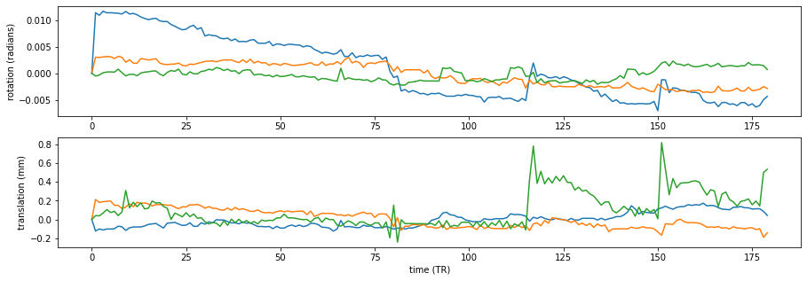

```python
# Plot the motion paramters
import numpy as np
import pylab as plt
par = np.loadtxt('/Users/hanningsu/Desktop/Nipype_Tutorial/hands_on_preprocessing/output/work_preproc/_subject_id_05/mcflirt/'
                 'asub-05_ses-test_task-fingerfootlips_bold_roi_mcf.nii.gz.par')
fig, axes = plt.subplots(2, 1, figsize=(15, 5))
axes[0].set_ylabel('rotation (radians)')
axes[0].plot(par[0:, :3])
axes[1].plot(par[0:, 3:])
axes[1].set_xlabel('time (TR)')
axes[1].set_ylabel('translation (mm)');
```

What about the detection of artifacts?

```python
# Showing the artifact detection output
from IPython.display import SVG
SVG(filename='/Users/hanningsu/Desktop/Nipype_Tutorial/hands_on_preprocessing/output/work_preproc/_subject_id_05/art/'
    'plot.asub-05_ses-test_task-fingerfootlips_bold_roi_mcf.svg')
```

[figure not shown]

Which volumes are problematic?

```python
outliers = np.loadtxt('/Users/hanningsu/Desktop/Nipype_Tutorial/hands_on_preprocessing/output/work_preproc/_subject_id_05/art/'
                      'art.asub-05_ses-test_task-fingerfootlips_bold_roi_mcf_outliers.txt')
list(outliers.astype('int'))
```

```
[15, 16, 17, 116, 123, 124, 151, 157, 158, 159]
```

## Masks and Probability maps

```python
from nilearn import image as nli
from nilearn.plotting import plot_stat_map
%matplotlib inline
output = '/Users/hanningsu/Desktop/Nipype_Tutorial/hands_on_preprocessing/output/work_preproc/_subject_id_05/'
```

```python
anat = output + 'gunzip_anat/sub-05_ses-test_T1w.nii'
```

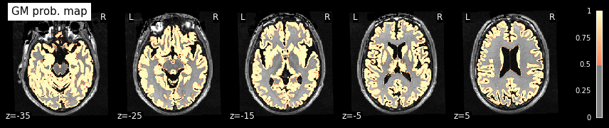

```python
plot_stat_map(
    output + 'segment/c1sub-05_ses-test_T1w.nii', title='GM prob. map',  cmap=plt.cm.magma,
    threshold=0.5, bg_img=anat, display_mode='z', cut_coords=range(-35, 15, 10), dim=-1);
```

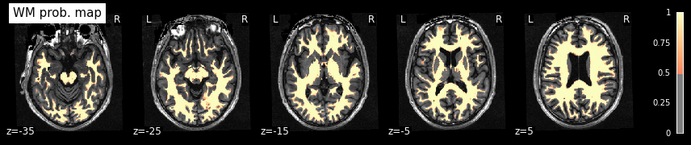

```python
plot_stat_map(
    output + 'segment/c2sub-05_ses-test_T1w.nii', title='WM prob. map', cmap=plt.cm.magma,
    threshold=0.5, bg_img=anat, display_mode='z', cut_coords=range(-35, 15, 10), dim=-1);
```

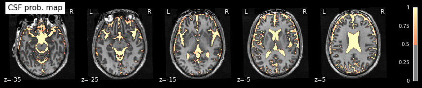

```python
plot_stat_map(
    output + 'segment/c3sub-05_ses-test_T1w.nii', title='CSF prob. map', cmap=plt.cm.magma,
    threshold=0.5, bg_img=anat, display_mode='z', cut_coords=range(-35, 15, 10), dim=-1);
```

## Functional Image Transformations

Let's also investigate the transformations that we applied to the functional images

```python
%matplotlib inline
from nilearn import image as nli
from nilearn.plotting import plot_epi
output = '/Users/hanningsu/Desktop/Nipype_Tutorial/hands_on_preprocessing/output/work_preproc/_subject_id_05/'
```

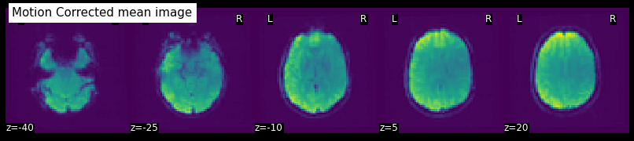

```python
plot_epi(output + 'mcflirt/asub-05_ses-test_task-fingerfootlips_bold_roi_mcf.nii.gz_mean_reg.nii.gz',
         title='Motion Corrected mean image', display_mode='z', cut_coords=range(-40, 21, 15),
         cmap=plt.cm.viridis);
```

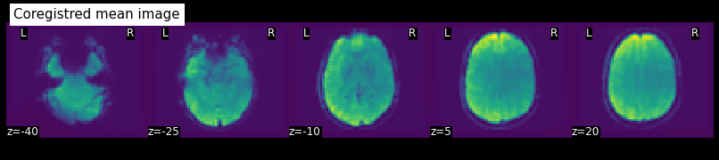

```python
mean = nli.mean_img(output + 'applywarp/asub-05_ses-test_task-fingerfootlips_bold_roi_mcf_flirt.nii')
plot_epi(mean, title='Coregistred mean image', display_mode='z', cut_coords=range(-40, 21, 15),
         cmap=plt.cm.viridis);
```

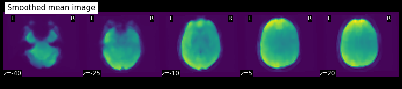

```python
mean = nli.mean_img(output + 'susan/asub-05_ses-test_task-fingerfootlips_bold_roi_mcf_flirt_smooth.nii.gz')
plot_epi(mean, title='Smoothed mean image', display_mode='z', cut_coords=range(-40, 21, 15),
         cmap=plt.cm.viridis); # Note that file location is different from tutorial
```

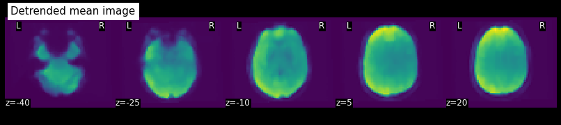

```python
plot_epi(output + 'detrend/mean.nii.gz', title='Detrended mean image', display_mode='z',
         cut_coords=range(-40, 21, 15), cmap=plt.cm.viridis);
```

what did smoothing and detrending actually do to the data?

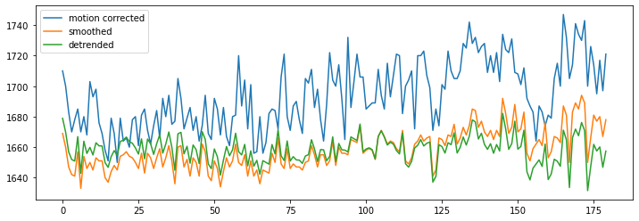

```python
%matplotlib inline
import nibabel as nb
output = '/Users/hanningsu/Desktop/Nipype_Tutorial/hands_on_preprocessing/output/work_preproc/_subject_id_05/'

# Load the relevant datasets
mc = nb.load(output + 'applywarp/asub-05_ses-test_task-fingerfootlips_bold_roi_mcf_flirt.nii')
smooth = nb.load(output + 'susan/asub-05_ses-test_task-fingerfootlips_bold_roi_mcf_flirt_smooth.nii.gz')
detrended_data = nb.load(output + 'detrend/detrend.nii.gz')

# Plot a representative voxel
x, y, z = 32, 34, 43
fig = plt.figure(figsize=(12, 4))
plt.plot(mc.get_data()[x, y, z, :])
plt.plot(smooth.get_data()[x, y, z, :])
plt.plot(detrended_data.get_data()[x, y, z, :])
plt.legend(['motion corrected', 'smoothed', 'detrended']);
```

## Data output with DataSink

We don't need all those temporary files. So let's use Datasink to keep only those files that we actually need for the 1st and 2nd level analysis.

```python
from nipype.interfaces.io import DataSink

# Initiate the datasink node
output_folder = 'datasink_handson'
datasink = Node(DataSink(base_directory='/Users/hanningsu/Desktop/Nipype_Tutorial/hands_on_preprocessing/output/',
                         container=output_folder),
                name="datasink")
```

We keep:

from the artifact detection node the outlier file as well as the outlier plot

from the motion correction node the motion parameters

from the last node, the detrended functional image

```python
# Connect nodes to datasink here
preproc.connect([(art, datasink, [('outlier_files', 'preproc.@outlier_files'),
                                  ('plot_files', 'preproc.@plot_files')]),
                 (mcflirt, datasink, [('par_file', 'preproc.@par')]),
                 (detrend, datasink, [('detrended_file', 'preproc.@func')]),
                 ])
```

# Run the workflow (again, keeping only necessary files)

```python
preproc.run('MultiProc', plugin_args={'n_procs': 8})
```

```
210812-05:50:24,756 nipype.workflow INFO:
	 Workflow work_preproc settings: ['check', 'execution', 'logging', 'monitoring']
210812-05:50:24,771 nipype.workflow INFO:
	 Running in parallel.
210812-05:50:24,774 nipype.workflow INFO:
	 [MultiProc] Running 0 tasks, and 1 jobs ready. Free memory (GB): 7.20/7.20, Free processors: 8/8.
210812-05:50:26,785 nipype.workflow INFO:
	 [MultiProc] Running 1 tasks, and 0 jobs ready. Free memory (GB): 7.00/7.20, Free processors: 7/8.
                     Currently running:
                       * work_preproc.selectfiles
210812-05:50:32,797 nipype.workflow INFO:
	 [Job 0] Completed (work_preproc.selectfiles).
210812-05:50:32,805 nipype.workflow INFO:
	 [MultiProc] Running 0 tasks, and 2 jobs ready. Free memory (GB): 7.20/7.20, Free processors: 8/8.
210812-05:50:32,879 nipype.workflow INFO:
	 [Job 1] Cached (work_preproc.gunzip_func).
210812-05:50:32,881 nipype.workflow INFO:
	 [Job 6] Cached (work_preproc.gunzip_anat).
210812-05:50:34,887 nipype.workflow INFO:
	 [Job 2] Cached (work_preproc.extract).
210812-05:50:34,890 nipype.workflow INFO:
	 [Job 7] Cached (work_preproc.segment).
210812-05:50:36,893 nipype.workflow INFO:
	 [Job 3] Cached (work_preproc.slicetime).
210812-05:50:36,896 nipype.workflow INFO:
	 [Job 8] Cached (work_preproc.threshold_WM).
210812-05:50:38,815 nipype.workflow INFO:
	 [MultiProc] Running 0 tasks, and 1 jobs ready. Free memory (GB): 7.20/7.20, Free processors: 8/8.
210812-05:50:38,897 nipype.workflow INFO:
	 [Job 4] Cached (work_preproc.mcflirt).
210812-05:50:40,815 nipype.workflow INFO:
	 [MultiProc] Running 0 tasks, and 2 jobs ready. Free memory (GB): 7.20/7.20, Free processors: 8/8.
210812-05:50:40,898 nipype.workflow INFO:
	 [Node] Outdated cache found for "work_preproc.art".
210812-05:50:40,902 nipype.workflow INFO:
	 [Job 9] Cached (work_preproc.coreg).
210812-05:50:42,820 nipype.workflow INFO:
	 [Job 5] Completed (work_preproc.art).
210812-05:50:42,827 nipype.workflow INFO:
	 [MultiProc] Running 0 tasks, and 1 jobs ready. Free memory (GB): 7.20/7.20, Free processors: 8/8.
210812-05:50:42,904 nipype.workflow INFO:
	 [Job 10] Cached (work_preproc.applywarp).
210812-05:50:44,910 nipype.workflow INFO:
	 [Job 11] Cached (work_preproc.susan).
210812-05:50:46,912 nipype.workflow INFO:
	 [Node] Outdated cache found for "work_preproc.detrend".
210812-05:50:48,835 nipype.workflow INFO:
	 [MultiProc] Running 1 tasks, and 0 jobs ready. Free memory (GB): 7.00/7.20, Free processors: 7/8.
                     Currently running:
                       * work_preproc.detrend
210812-05:50:50,842 nipype.workflow INFO:
	 [Job 12] Completed (work_preproc.detrend).
210812-05:50:50,849 nipype.workflow INFO:
	 [MultiProc] Running 0 tasks, and 1 jobs ready. Free memory (GB): 7.20/7.20, Free processors: 8/8.
210812-05:50:52,847 nipype.workflow INFO:
	 [Job 13] Completed (work_preproc.datasink).
210812-05:50:52,854 nipype.workflow INFO:
	 [MultiProc] Running 0 tasks, and 0 jobs ready. Free memory (GB): 7.20/7.20, Free processors: 8/8.
```

```
<networkx.classes.digraph.DiGraph at 0x7fd62565fd30>
```

Let's look now at the output of this datasink folder.

```python
!tree /Users/hanningsu/Desktop/Nipype_Tutorial/hands_on_preprocessing/output/datasink_handson -I '*js|*json|*pklz|_report|*dot|*html|*txt|*.m'
```

```
/Users/hanningsu/Desktop/Nipype_Tutorial/hands_on_preprocessing/output/datasink_handson
└── preproc
    └── _subject_id_05
        ├── asub-05_ses-test_task-fingerfootlips_bold_roi_mcf.nii.gz.par
        ├── detrend.nii.gz
        └── plot.asub-05_ses-test_task-fingerfootlips_bold_roi_mcf.svg

2 directories, 3 files
```

There are many unnecessary file specifiers that we can get rid off. To do so, we can use DataSink's substitutions parameter. For this, we create a list of tuples: on the left, we specify the string that we want to replace and on the right, with what we want to replace it with.

```python
## Use the following substitutions for the DataSink output
substitutions = [('asub', 'sub'),
                 ('_ses-test_task-fingerfootlips_bold_roi_mcf', ''),
                 ('.nii.gz.par', '.par'),
                 ]

# To get rid of the folder '_subject_id_07' and renaming detrend
substitutions += [('_subject_id_%s/detrend' % s,
                   '_subject_id_%s/sub-%s_detrend' % (s, s)) for s in subject_list]
substitutions += [('_subject_id_%s/' % s, '') for s in subject_list]
datasink.inputs.substitutions = substitutions
```

```python
# Delets the current output folder
!rm -rf /Users/hanningsu/Desktop/Nipype_Tutorial/hands_on_preprocessing/output/datasink_handson
```

```python
# Runs the preprocessing workflow again, this time with substitutions
preproc.run('MultiProc', plugin_args={'n_procs': 8})
```

```
210812-05:52:05,452 nipype.workflow INFO:
	 Workflow work_preproc settings: ['check', 'execution', 'logging', 'monitoring']
210812-05:52:05,467 nipype.workflow INFO:
	 Running in parallel.
210812-05:52:05,469 nipype.workflow INFO:
	 [MultiProc] Running 0 tasks, and 1 jobs ready. Free memory (GB): 7.20/7.20, Free processors: 8/8.
210812-05:52:07,483 nipype.workflow INFO:
	 [MultiProc] Running 1 tasks, and 0 jobs ready. Free memory (GB): 7.00/7.20, Free processors: 7/8.
                     Currently running:
                       * work_preproc.selectfiles
210812-05:52:13,490 nipype.workflow INFO:
	 [Job 0] Completed (work_preproc.selectfiles).
210812-05:52:13,498 nipype.workflow INFO:
	 [MultiProc] Running 0 tasks, and 2 jobs ready. Free memory (GB): 7.20/7.20, Free processors: 8/8.
210812-05:52:13,571 nipype.workflow INFO:
	 [Job 1] Cached (work_preproc.gunzip_func).
210812-05:52:13,573 nipype.workflow INFO:
	 [Job 6] Cached (work_preproc.gunzip_anat).
210812-05:52:15,581 nipype.workflow INFO:
	 [Job 2] Cached (work_preproc.extract).
210812-05:52:15,583 nipype.workflow INFO:
	 [Job 7] Cached (work_preproc.segment).
210812-05:52:17,593 nipype.workflow INFO:
	 [Job 3] Cached (work_preproc.slicetime).
210812-05:52:17,595 nipype.workflow INFO:
	 [Job 8] Cached (work_preproc.threshold_WM).
210812-05:52:19,508 nipype.workflow INFO:
	 [MultiProc] Running 0 tasks, and 1 jobs ready. Free memory (GB): 7.20/7.20, Free processors: 8/8.
210812-05:52:19,593 nipype.workflow INFO:
	 [Job 4] Cached (work_preproc.mcflirt).
210812-05:52:21,514 nipype.workflow INFO:
	 [MultiProc] Running 0 tasks, and 2 jobs ready. Free memory (GB): 7.20/7.20, Free processors: 8/8.
210812-05:52:21,600 nipype.workflow INFO:
	 [Job 5] Cached (work_preproc.art).
210812-05:52:21,603 nipype.workflow INFO:
	 [Job 9] Cached (work_preproc.coreg).
210812-05:52:23,519 nipype.workflow INFO:
	 [MultiProc] Running 0 tasks, and 1 jobs ready. Free memory (GB): 7.20/7.20, Free processors: 8/8.
210812-05:52:23,603 nipype.workflow INFO:
	 [Job 10] Cached (work_preproc.applywarp).
210812-05:52:25,607 nipype.workflow INFO:
	 [Job 11] Cached (work_preproc.susan).
210812-05:52:27,611 nipype.workflow INFO:
	 [Job 12] Cached (work_preproc.detrend).
210812-05:52:29,636 nipype.workflow INFO:
	 [Node] Outdated cache found for "work_preproc.datasink".
210812-05:52:31,539 nipype.workflow INFO:
	 [Job 13] Completed (work_preproc.datasink).
210812-05:52:31,546 nipype.workflow INFO:
	 [MultiProc] Running 0 tasks, and 0 jobs ready. Free memory (GB): 7.20/7.20, Free processors: 8/8.
```

```
<networkx.classes.digraph.DiGraph at 0x7fd62565f9d0>
```

```python
!tree /Users/hanningsu/Desktop/Nipype_Tutorial/hands_on_preprocessing/output/datasink_handson -I '*js|*json|*pklz|_report|*dot|*html|*.m'
```

```
/Users/hanningsu/Desktop/Nipype_Tutorial/hands_on_preprocessing/output/datasink_handson
└── preproc
    ├── art.sub-05_outliers.txt
    ├── plot.sub-05.svg
    ├── sub-05.par
    └── sub-05_detrend.nii.gz

1 directory, 4 files
```

## Run Preprocessing workflow on all right-handed subjects

```python
# Update 'subject_list' and its dependencies here
```

```python
#subject_list = ['02', '03', '04', '07', '08', '09']
subject_list = ['02', '03']

sf.iterables = [('subject_id', subject_list)]
```

```python
# To get rid of the folder '_subject_id_02' and renaming detrend
substitutions += [('_subject_id_%s/detrend' % s,
                   '_subject_id_%s/sub-%s_detrend' % (s, s)) for s in subject_list]
substitutions += [('_subject_id_%s/' % s, '') for s in subject_list]
datasink.inputs.substitutions = substitutions
```

```python
# Runs the preprocessing workflow again, this time with substitutions
preproc.run('MultiProc', plugin_args={'n_procs': 8})
```

```
210812-06:17:05,504 nipype.workflow INFO:
	 Workflow work_preproc settings: ['check', 'execution', 'logging', 'monitoring']
210812-06:17:05,526 nipype.workflow INFO:
	 Running in parallel.
210812-06:17:05,528 nipype.workflow INFO:
	 [MultiProc] Running 0 tasks, and 2 jobs ready. Free memory (GB): 7.20/7.20, Free processors: 8/8.
210812-06:17:07,535 nipype.workflow INFO:
	 [MultiProc] Running 2 tasks, and 0 jobs ready. Free memory (GB): 6.80/7.20, Free processors: 6/8.
                     Currently running:
                       * work_preproc.selectfiles
                       * work_preproc.selectfiles
210812-06:17:09,538 nipype.workflow INFO:
	 [Job 0] Completed (work_preproc.selectfiles).
210812-06:17:09,543 nipype.workflow INFO:
	 [Job 14] Completed (work_preproc.selectfiles).
210812-06:17:09,549 nipype.workflow INFO:
	 [MultiProc] Running 0 tasks, and 4 jobs ready. Free memory (GB): 7.20/7.20, Free processors: 8/8.
210812-06:17:11,543 nipype.workflow INFO:
	 [Job 1] Completed (work_preproc.gunzip_func).
210812-06:17:11,548 nipype.workflow INFO:
	 [Job 6] Completed (work_preproc.gunzip_anat).
210812-06:17:11,552 nipype.workflow INFO:
	 [Job 15] Completed (work_preproc.gunzip_func).
210812-06:17:11,555 nipype.workflow INFO:
	 [Job 20] Completed (work_preproc.gunzip_anat).
210812-06:17:11,560 nipype.workflow INFO:
	 [MultiProc] Running 0 tasks, and 4 jobs ready. Free memory (GB): 7.20/7.20, Free processors: 8/8.
210812-06:17:13,545 nipype.workflow INFO:
	 [Job 2] Completed (work_preproc.extract).
210812-06:17:13,546 nipype.workflow INFO:
	 [Job 16] Completed (work_preproc.extract).
210812-06:17:13,548 nipype.workflow INFO:
	 [MultiProc] Running 2 tasks, and 2 jobs ready. Free memory (GB): 6.80/7.20, Free processors: 6/8.
                     Currently running:
                       * work_preproc.segment
                       * work_preproc.segment
210812-06:17:15,551 nipype.workflow INFO:
	 [MultiProc] Running 4 tasks, and 0 jobs ready. Free memory (GB): 6.40/7.20, Free processors: 4/8.
                     Currently running:
                       * work_preproc.slicetime
```

[output cut: 113 more lines]

```
	 [Job 12] Completed (work_preproc.detrend).
210812-06:22:18,302 nipype.workflow INFO:
	 [MultiProc] Running 1 tasks, and 1 jobs ready. Free memory (GB): 7.00/7.20, Free processors: 7/8.
                     Currently running:
                       * work_preproc.detrend
210812-06:22:20,310 nipype.workflow INFO:
	 [Job 26] Completed (work_preproc.detrend).
210812-06:22:20,316 nipype.workflow INFO:
	 [Job 13] Completed (work_preproc.datasink).
210812-06:22:20,321 nipype.workflow INFO:
	 [MultiProc] Running 0 tasks, and 1 jobs ready. Free memory (GB): 7.20/7.20, Free processors: 8/8.
210812-06:22:22,315 nipype.workflow INFO:
	 [Job 27] Completed (work_preproc.datasink).
210812-06:22:22,322 nipype.workflow INFO:
	 [MultiProc] Running 0 tasks, and 0 jobs ready. Free memory (GB): 7.20/7.20, Free processors: 8/8.
```

```
<networkx.classes.digraph.DiGraph at 0x7fd625648100>
```

```python
!tree /Users/hanningsu/Desktop/Nipype_Tutorial/hands_on_preprocessing/output/datasink_handson -I '*js|*json|*pklz|_report|*dot|*html|*.m'
```

```
/Users/hanningsu/Desktop/Nipype_Tutorial/hands_on_preprocessing/output/datasink_handson
└── preproc
    ├── art.sub-02_outliers.txt
    ├── art.sub-03_outliers.txt
    ├── plot.sub-02.svg
    ├── plot.sub-03.svg
    ├── sub-02.par
    ├── sub-02_detrend.nii.gz
    ├── sub-03.par
    └── sub-03_detrend.nii.gz

1 directory, 8 files
```

```python
subject_list = ['04', '07']

sf.iterables = [('subject_id', subject_list)]
```

```python
# To get rid of the folder '_subject_id_02' and renaming detrend
substitutions += [('_subject_id_%s/detrend' % s,
                   '_subject_id_%s/sub-%s_detrend' % (s, s)) for s in subject_list]
substitutions += [('_subject_id_%s/' % s, '') for s in subject_list]
datasink.inputs.substitutions = substitutions
```

```python
# Runs the preprocessing workflow again, this time with substitutions
preproc.run('MultiProc', plugin_args={'n_procs': 8})
```

```
210812-06:24:36,53 nipype.workflow INFO:
	 Workflow work_preproc settings: ['check', 'execution', 'logging', 'monitoring']
210812-06:24:36,75 nipype.workflow INFO:
	 Running in parallel.
210812-06:24:36,78 nipype.workflow INFO:
	 [MultiProc] Running 0 tasks, and 2 jobs ready. Free memory (GB): 7.20/7.20, Free processors: 8/8.
210812-06:24:38,89 nipype.workflow INFO:
	 [MultiProc] Running 2 tasks, and 0 jobs ready. Free memory (GB): 6.80/7.20, Free processors: 6/8.
                     Currently running:
                       * work_preproc.selectfiles
                       * work_preproc.selectfiles
210812-06:24:40,90 nipype.workflow INFO:
	 [Job 0] Completed (work_preproc.selectfiles).
210812-06:24:40,95 nipype.workflow INFO:
	 [Job 14] Completed (work_preproc.selectfiles).
210812-06:24:40,103 nipype.workflow INFO:
	 [MultiProc] Running 0 tasks, and 4 jobs ready. Free memory (GB): 7.20/7.20, Free processors: 8/8.
210812-06:24:42,94 nipype.workflow INFO:
	 [Job 1] Completed (work_preproc.gunzip_func).
210812-06:24:42,99 nipype.workflow INFO:
	 [Job 6] Completed (work_preproc.gunzip_anat).
210812-06:24:42,102 nipype.workflow INFO:
	 [Job 15] Completed (work_preproc.gunzip_func).
210812-06:24:42,105 nipype.workflow INFO:
	 [Job 20] Completed (work_preproc.gunzip_anat).
210812-06:24:42,109 nipype.workflow INFO:
	 [MultiProc] Running 0 tasks, and 4 jobs ready. Free memory (GB): 7.20/7.20, Free processors: 8/8.
210812-06:24:44,97 nipype.workflow INFO:
	 [Job 2] Completed (work_preproc.extract).
210812-06:24:44,99 nipype.workflow INFO:
	 [Job 16] Completed (work_preproc.extract).
210812-06:24:44,100 nipype.workflow INFO:
	 [MultiProc] Running 2 tasks, and 2 jobs ready. Free memory (GB): 6.80/7.20, Free processors: 6/8.
                     Currently running:
                       * work_preproc.segment
                       * work_preproc.segment
210812-06:24:46,104 nipype.workflow INFO:
	 [MultiProc] Running 4 tasks, and 0 jobs ready. Free memory (GB): 6.40/7.20, Free processors: 4/8.
                     Currently running:
                       * work_preproc.slicetime
```

[output cut: 136 more lines]

```
	 [Job 25] Completed (work_preproc.susan).
210812-06:30:04,887 nipype.workflow INFO:
	 [MultiProc] Running 0 tasks, and 1 jobs ready. Free memory (GB): 7.20/7.20, Free processors: 8/8.
210812-06:30:06,891 nipype.workflow INFO:
	 [MultiProc] Running 1 tasks, and 0 jobs ready. Free memory (GB): 7.00/7.20, Free processors: 7/8.
                     Currently running:
                       * work_preproc.detrend
210812-06:30:08,896 nipype.workflow INFO:
	 [Job 26] Completed (work_preproc.detrend).
210812-06:30:08,901 nipype.workflow INFO:
	 [MultiProc] Running 0 tasks, and 1 jobs ready. Free memory (GB): 7.20/7.20, Free processors: 8/8.
210812-06:30:10,903 nipype.workflow INFO:
	 [Job 27] Completed (work_preproc.datasink).
210812-06:30:10,908 nipype.workflow INFO:
	 [MultiProc] Running 0 tasks, and 0 jobs ready. Free memory (GB): 7.20/7.20, Free processors: 8/8.
```

```
<networkx.classes.digraph.DiGraph at 0x7fd625648280>
```

```python
!tree /Users/hanningsu/Desktop/Nipype_Tutorial/hands_on_preprocessing/output/datasink_handson -I '*js|*json|*pklz|_report|*dot|*html|*.m'
```

```
/Users/hanningsu/Desktop/Nipype_Tutorial/hands_on_preprocessing/output/datasink_handson
└── preproc
    ├── art.sub-02_outliers.txt
    ├── art.sub-03_outliers.txt
    ├── art.sub-04_outliers.txt
    ├── art.sub-07_outliers.txt
    ├── plot.sub-02.svg
    ├── plot.sub-03.svg
    ├── plot.sub-04.svg
    ├── plot.sub-07.svg
    ├── sub-02.par
    ├── sub-02_detrend.nii.gz
    ├── sub-03.par
    ├── sub-03_detrend.nii.gz
    ├── sub-04.par
    ├── sub-04_detrend.nii.gz
    ├── sub-07.par
    └── sub-07_detrend.nii.gz

1 directory, 16 files
```

```python
subject_list = ['08', '09']

sf.iterables = [('subject_id', subject_list)]
```

```python
# To get rid of the folder '_subject_id_02' and renaming detrend
substitutions += [('_subject_id_%s/detrend' % s,
                   '_subject_id_%s/sub-%s_detrend' % (s, s)) for s in subject_list]
substitutions += [('_subject_id_%s/' % s, '') for s in subject_list]
datasink.inputs.substitutions = substitutions
```

```python
# Runs the preprocessing workflow again, this time with substitutions
preproc.run('MultiProc', plugin_args={'n_procs': 8})
```

```
210812-06:34:11,939 nipype.workflow INFO:
	 Workflow work_preproc settings: ['check', 'execution', 'logging', 'monitoring']
210812-06:34:11,960 nipype.workflow INFO:
	 Running in parallel.
210812-06:34:11,963 nipype.workflow INFO:
	 [MultiProc] Running 0 tasks, and 2 jobs ready. Free memory (GB): 7.20/7.20, Free processors: 8/8.
210812-06:34:13,968 nipype.workflow INFO:
	 [MultiProc] Running 2 tasks, and 0 jobs ready. Free memory (GB): 6.80/7.20, Free processors: 6/8.
                     Currently running:
                       * work_preproc.selectfiles
                       * work_preproc.selectfiles
210812-06:34:15,971 nipype.workflow INFO:
	 [Job 0] Completed (work_preproc.selectfiles).
210812-06:34:15,974 nipype.workflow INFO:
	 [Job 14] Completed (work_preproc.selectfiles).
210812-06:34:15,978 nipype.workflow INFO:
	 [MultiProc] Running 0 tasks, and 4 jobs ready. Free memory (GB): 7.20/7.20, Free processors: 8/8.
210812-06:34:17,976 nipype.workflow INFO:
	 [Job 1] Completed (work_preproc.gunzip_func).
210812-06:34:17,979 nipype.workflow INFO:
	 [Job 6] Completed (work_preproc.gunzip_anat).
210812-06:34:17,981 nipype.workflow INFO:
	 [Job 15] Completed (work_preproc.gunzip_func).
210812-06:34:17,983 nipype.workflow INFO:
	 [Job 20] Completed (work_preproc.gunzip_anat).
210812-06:34:17,986 nipype.workflow INFO:
	 [MultiProc] Running 0 tasks, and 4 jobs ready. Free memory (GB): 7.20/7.20, Free processors: 8/8.
210812-06:34:19,980 nipype.workflow INFO:
	 [Job 2] Completed (work_preproc.extract).
210812-06:34:19,981 nipype.workflow INFO:
	 [Job 16] Completed (work_preproc.extract).
210812-06:34:19,982 nipype.workflow INFO:
	 [MultiProc] Running 2 tasks, and 2 jobs ready. Free memory (GB): 6.80/7.20, Free processors: 6/8.
                     Currently running:
                       * work_preproc.segment
                       * work_preproc.segment
210812-06:34:21,986 nipype.workflow INFO:
	 [MultiProc] Running 4 tasks, and 0 jobs ready. Free memory (GB): 6.40/7.20, Free processors: 4/8.
                     Currently running:
                       * work_preproc.slicetime
```

[output cut: 134 more lines]

```
	 [Job 25] Completed (work_preproc.susan).
210812-06:39:50,824 nipype.workflow INFO:
	 [MultiProc] Running 0 tasks, and 1 jobs ready. Free memory (GB): 7.20/7.20, Free processors: 8/8.
210812-06:39:52,820 nipype.workflow INFO:
	 [MultiProc] Running 1 tasks, and 0 jobs ready. Free memory (GB): 7.00/7.20, Free processors: 7/8.
                     Currently running:
                       * work_preproc.detrend
210812-06:39:54,827 nipype.workflow INFO:
	 [Job 26] Completed (work_preproc.detrend).
210812-06:39:54,836 nipype.workflow INFO:
	 [MultiProc] Running 0 tasks, and 1 jobs ready. Free memory (GB): 7.20/7.20, Free processors: 8/8.
210812-06:39:56,827 nipype.workflow INFO:
	 [Job 27] Completed (work_preproc.datasink).
210812-06:39:56,831 nipype.workflow INFO:
	 [MultiProc] Running 0 tasks, and 0 jobs ready. Free memory (GB): 7.20/7.20, Free processors: 8/8.
```

```
<networkx.classes.digraph.DiGraph at 0x7fd623855040>
```

```python
!tree /Users/hanningsu/Desktop/Nipype_Tutorial/hands_on_preprocessing/output/datasink_handson -I '*js|*json|*pklz|_report|*dot|*html|*.m'
```

```
/Users/hanningsu/Desktop/Nipype_Tutorial/hands_on_preprocessing/output/datasink_handson
└── preproc
    ├── art.sub-02_outliers.txt
    ├── art.sub-03_outliers.txt
    ├── art.sub-04_outliers.txt
    ├── art.sub-07_outliers.txt
    ├── art.sub-08_outliers.txt
    ├── art.sub-09_outliers.txt
    ├── plot.sub-02.svg
    ├── plot.sub-03.svg
    ├── plot.sub-04.svg
    ├── plot.sub-07.svg
    ├── plot.sub-08.svg
    ├── plot.sub-09.svg
    ├── sub-02.par
    ├── sub-02_detrend.nii.gz
    ├── sub-03.par
    ├── sub-03_detrend.nii.gz
    ├── sub-04.par
    ├── sub-04_detrend.nii.gz
    ├── sub-07.par
    ├── sub-07_detrend.nii.gz
    ├── sub-08.par
    ├── sub-08_detrend.nii.gz
    ├── sub-09.par
    └── sub-09_detrend.nii.gz

1 directory, 24 files
```